# S-Mobile: Predicting Customer Churn

- Team-lead gitlab id: 2724742
- Group number: 10
- Group name: Group_10
- Team member names: Menghui Zhang, Shumeng Shi, Wenrui Li

### Setup

Please complete this R-markdown document by answering the questions in `s-mobile.pdf` on Dropbox (week9/readings/). The code block below will load the data you will need. Please DO NOT change the code used to load the data. Create an HTML file with all your results and comments and push both the Rmarkdown and HTML file to GitLab when you are done. All analysis results MUST be reproducible (i.e., the TA and I must be able to recreate the HTML from the R-markdown file without changes or errors). Upload all files to GitLab.

```r
## Loading the data from Dropbox
s_mobile <- readr::read_rds(file.path(radiant.data::find_dropbox(), "MGTA455-2019/data/s_mobile.rds"))
```

```r
# log transformation for 'mou' variable
s_mobile$mou_log <- log(s_mobile$mou + 1)

# split into training, validation and representative data
train <- s_mobile %>%
  filter(training == 1)

validation <- s_mobile %>%
  filter(training == 0)

representative <- s_mobile %>%
  filter(representative == 1)
```

### Question 1 - Build Predictive Model

#### Logistic Regression

We hand picked the variables whose coefficients are statistically significant at 10% level. Below is model summary.

```r
logit_result <- logistic(
  train,
  rvar = "churn",
  evar = c(
    "changer", "changem", "overage", "roam", "conference",
    "months", "uniqsubs", "retcalls", "dropvce", "eqpdays",
    "refurb", "highcreditr", "mcycle", "travel", "region", "occupation",
    "mou_log", "revenue"
  ),
  lev = "yes",
  check = "standardize"
)

summary(logit_result)
```

```
Logistic regression (GLM)
Data                 : train
Response variable    : churn
Level                : yes in churn
Explanatory variables: changer, changem, overage, roam, conference, months, uniqsubs, retcalls, dropvce, eqpdays, refurb, highcreditr, mcycle, travel, region, occupation, mou_log, revenue
Null hyp.: there is no effect of x on churn
Alt. hyp.: there is an effect of x on churn
**Standardized odds-ratios and coefficients shown (2 X SD)**

                            OR coefficient std.error z.value p.value
 (Intercept)                         0.410     0.030  13.767  < .001 ***
 changer                 1.057       0.056     0.030   1.885   0.059 .
 changem                 0.862      -0.149     0.029  -5.173  < .001 ***
 overage                 1.912       0.648     0.034  18.978  < .001 ***
 roam                    1.156       0.145     0.034   4.229  < .001 ***
 conference              0.942      -0.060     0.028  -2.167   0.030 *
 months                  0.722      -0.326     0.030 -10.710  < .001 ***
 uniqsubs                1.076       0.073     0.026   2.800   0.005 **
 retcalls                1.355       0.304     0.028  10.782  < .001 ***
 dropvce                 1.113       0.107     0.031   3.429  < .001 ***
 eqpdays                 1.872       0.627     0.033  19.193  < .001 ***
 refurb|yes              1.349       0.299     0.038   7.924  < .001 ***
 highcreditr|yes         0.490      -0.714     0.040 -18.068  < .001 ***
 mcycle|yes              0.904      -0.101     0.033  -3.008   0.003 **
 travel|yes              0.785      -0.243     0.058  -4.170  < .001 ***
 region|NE               0.646      -0.436     0.040 -10.970  < .001 ***
 region|NW               0.665      -0.407     0.040 -10.278  < .001 ***
 region|SE               0.656      -0.422     0.040 -10.653  < .001 ***
 region|SW               0.635      -0.454     0.040 -11.438  < .001 ***
 occupation|professional 1.428       0.356     0.033  10.697  < .001 ***
 occupation|student      1.845       0.612     0.050  12.128  < .001 ***
 occupation|retired      0.183      -1.700     0.061 -27.791  < .001 ***
 mou_log                 0.613      -0.489     0.035 -13.996  < .001 ***
 revenue                 0.923      -0.080     0.036  -2.213   0.027 *

Signif. codes:  0 '***' 0.001 '**' 0.01 '*' 0.05 '.' 0.1 ' ' 1

Pseudo R-squared: 0.089
Log-likelihood: -17246.117, AIC: 34540.235, BIC: 34737.386
Chi-squared: 3353.601 df(23), p.value < .001
Nr obs: 27,300
```

```r
# predict on validation data for further comparison

pred_logit <- predict(logit_result, pred_data = validation)$Prediction
```

#### Neural Network

In this part, we tune neural network model by iterating over size 3 to 10, with decay rate from 0.1 to 0.8. The highest validation AUC is achieved by size 10 and decay rate of 0.1.

```r
### tune neural network
params <- expand.grid(size = seq(3,10,1), decay = seq(0.1, 0.8, 0.1))
params$auc <- NA

real_churn <- ifelse(validation$churn == "yes", 1, 0)
for (i in 1:nrow(params)){
  result <- nn(
    train,
    rvar = "churn",
    evar = c(
      "changer", "changem", "revenue", "mou", "overage", "roam",
      "conference", "months", "uniqsubs", "custcare", "retcalls",
      "dropvce", "eqpdays", "refurb", "smartphone", "highcreditr",
      "mcycle", "car", "travel", "region", "occupation"
    ),
    lev = "yes",
    size = params[i,1],
    decay = params[i,2],
    seed = 1234
  )

  pred <- predict(result, pred_data = validation)$Prediction

  auc <- ModelMetrics::auc(real_churn, pred)
  params[i,3] <- auc

}

saveRDS(params, 'nn_tune.rds')
```

```r
nn_tune <- readRDS("nn_tune.rds")
pos <- which.max(nn_tune$auc)

result <- nn(
    train,
    rvar = "churn",
    evar = c(
      "changer", "changem", "revenue", "mou", "overage", "roam",
      "conference", "months", "uniqsubs", "custcare", "retcalls",
      "dropvce", "eqpdays", "refurb", "smartphone", "highcreditr",
      "mcycle", "car", "travel", "region", "occupation"
    ),
    lev = "yes",
    size = nn_tune[pos,1],
    decay = nn_tune[pos,2],
    seed = 1234
  )

pred_nn <- predict(result, pred_data = validation)$Prediction
```

#### Evaluate Models

Comparing prediction accuracy, AUC and true positive rate, we can see that neural network outperforms logistic regression in terms of accuracy and AUC, but underperforms in true positive rate. Since the performance difference isn’t substantial, and the key purpose of our analysis is to locate the main drivers for churn rate, we’ll use logistic regression for our further analysis.

```r
# define evaluation function
acc <- function(dat, vars){

  cm_df <- as.data.frame(matrix(NA, ncol = 4, nrow = length(vars)))
  colnames(cm_df) <- c("var", "acc", "tpr", "auc")

  for (i in 1:length(vars)){

    var <- vars[i]
    probs <- pull(dat, !!var)
    churn <- pull(dat, "churn")

    pred <- ifelse(pull(dat, !!var) > 0.5, "yes", "no")

    acc <- sum(churn == pred)/nrow(dat)
    tpr <- sum(churn == "yes" & pred == "yes")/sum(churn == "yes")
    auc <- ModelMetrics::auc(ifelse(churn=="yes",1,0), probs)

    cm_vec <- c(var, acc, tpr, auc)
    cm_df[i,] <- cm_vec

    cm_df[2:4] <- lapply(cm_df[2:4], as.numeric)
  }
  return(cm_df)
}

vars <- c("pred_logit", "pred_nn")
eval_df <- validation %>%
  select(churn) %>%
  mutate(pred_logit = pred_logit, pred_nn = pred_nn)

acc(eval_df, vars)
```

```
         var       acc       tpr       auc
1 pred_logit 0.6387179 0.6784615 0.6984786
2    pred_nn 0.6757265 0.6688889 0.7478364
```

### Question 2 - Main Driver Analysis

After choosing the suitable model, we train on the entire dataset (training + validation) and then analyze the main drivers to customer churning.

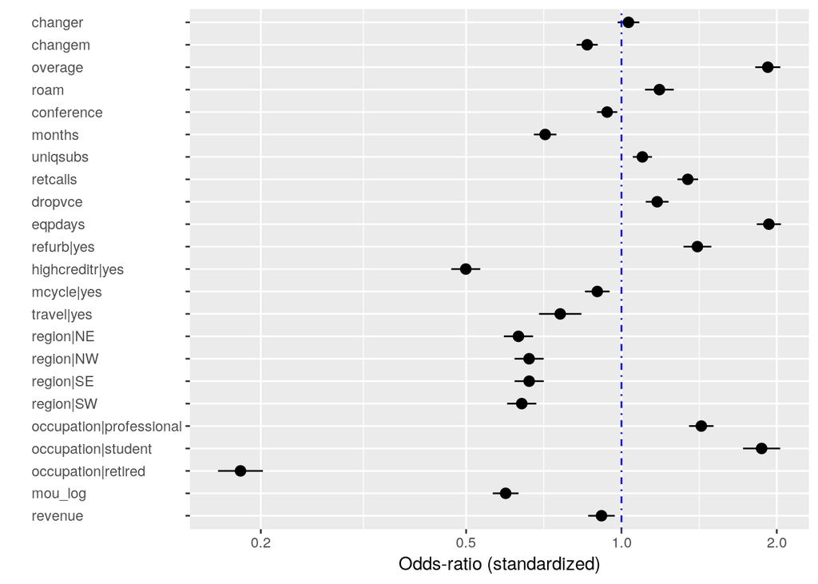

```r
entire_train <- rbind(train, validation)
result <- logistic(
  entire_train,
  rvar = "churn",
  evar = c(
    "changer", "changem", "overage", "roam", "conference",
    "months", "uniqsubs", "retcalls", "dropvce", "eqpdays",
    "refurb", "highcreditr", "mcycle", "travel", "region", "occupation",
    "mou_log", "revenue"
  ),
  lev = "yes",
  check = "standardize"
)
plot(result, plots = "coef", custom = FALSE)
```

Some odds ratios are less than 1 and some larger, we’ll convert to the same scale for comparison.

```r
coef_table <- result %>% write.coeff(intercept = FALSE) %>%
  format_df(dec = 4) %>%
  select(label, OR, coefficient, std.error, z.value, p.value) %>%
  mutate_at(vars(label), list(as.factor)) %>%
  mutate_at(vars(-label), list(as.numeric)) %>%
  mutate(importance = ifelse(OR >1, OR, 1.0/OR)) %>%
  arrange(desc(importance))
```

```
Standardized coefficients selected
```

```r
coef_table
```

```
                     label     OR coefficient std.error  z.value p.value importance
1       occupation|retired 0.1827     -1.7002    0.0511 -33.3038  0.0000   5.473454
2          highcreditr|yes 0.4992     -0.6947    0.0330 -21.0300  0.0000   2.003205
3                  eqpdays 1.9309      0.6580    0.0275  23.8988  0.0000   1.930900
4                  overage 1.9216      0.6532    0.0286  22.8705  0.0000   1.921600
5       occupation|student 1.8694      0.6256    0.0423  14.8075  0.0000   1.869400
6                  mou_log 0.5964     -0.5168    0.0294 -17.5878  0.0000   1.676727
7                region|NE 0.6315     -0.4597    0.0332 -13.8271  0.0000   1.583531
8                region|SW 0.6409     -0.4449    0.0332 -13.3928  0.0000   1.560306
9                region|NW 0.6623     -0.4121    0.0332 -12.4231  0.0000   1.509890
10               region|SE 0.6625     -0.4118    0.0333 -12.3826  0.0000   1.509434
11 occupation|professional 1.4283      0.3565    0.0279  12.7899  0.0000   1.428300
12                  months 0.7115     -0.3404    0.0256 -13.2830  0.0000   1.405481
13              refurb|yes 1.4035      0.3390    0.0316  10.7199  0.0000   1.403500
14                retcalls 1.3444      0.2960    0.0235  12.5816  0.0000   1.344400
15              travel|yes 0.7609     -0.2732    0.0483  -5.6597  0.0000   1.314233
16                    roam 1.1846      0.1694    0.0328   5.1598  0.0000   1.184600
17                 dropvce 1.1729      0.1594    0.0259   6.1546  0.0000   1.172900
18                 changem 0.8582     -0.1529    0.0241  -6.3515  0.0000   1.165230
19              mcycle|yes 0.8978     -0.1078    0.0280  -3.8460  0.0001   1.113834
20                uniqsubs 1.0979      0.0934    0.0218   4.2776  0.0000   1.097900
21                 revenue 0.9148     -0.0891    0.0303  -2.9412  0.0033   1.093135
22              conference 0.9382     -0.0638    0.0231  -2.7621  0.0057   1.065871
23                 changer 1.0319      0.0314    0.0246   1.2751  0.2023   1.031900
```

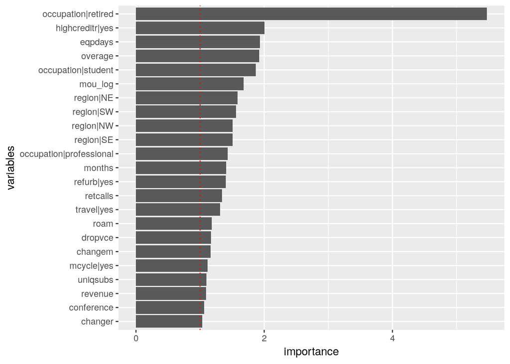

```r
coef_table %>%
  ggplot(aes(x = fct_reorder(label, importance), y = importance)) +
  geom_bar(stat = "identity") +
  coord_flip() +
  geom_hline(yintercept = 1.0, linetype = 'dotted', color = 'red')+
  labs(main = "Variable Importance in Churn Rate Prediction",
       x = "variables",
       y = 'importance')
```

Based on both importance table and plot, we find following main drivers.

1. Overage

Statistically speaking, 2 standard deviations increase in overage, equivalent to 138.49 minutes, would increase the odds of churning by 1.92 times, keeping everything else constant. This is probably because customers find the current plan unable to satisfy their needs and hence considering switching to other carriers.

2. Mean monthly minutes of use (log)

Similarly, 2 standard deviations increase in log-transformed ‘mean monthly minutes of use’, which is equivalent to around 18 minutes, would decrease the odds of customer churning by approximately 40%.

3. Occupation
- Retired - statistically speaking, odds of retired customer churning decrease by 82% compared to average customers (occupation|others), keeping everything else constant. This is probably because senior customers tend to have less expectation on mobile service, thus they are less picky. They are also reluctant to accept new things and they won’t bother calling to leave S-mobile.
- Student - statistically speaking, odds of student customer churning increase by a factor of 1.87, compared to average customers (occupation|others), keeping everything else constant. This is probably because students have relatively more choices in mobile service and they have less stable financial support, which both make them more likely to churn.
- Professional - statistically speaking, odds of professional customer churning increase by a factor of 1.42, compared to other customers, keeping everything else constant. This is probably because prefessionals are really comfortable in accepting new changes and they have high demand in a good quality mobile service. Once their need is unsatisfied, they tend to churn and switch to other providers.
4. Region
- SW,NE,SE,NW - statistically speaking, odds of churning of customers living in southwest, northeast, southeast, and northwest Singapore decrease by about 35% compared to customers from central Singapore, keeping everything else constant. Central singapore is the main metropolitan region and central business district. Many famous landmarks are located there, such as merlion park, making it the most expensive area in Singapore. Thus, we can assume that residents in central singapore tend to have higher standards on mobile services and would be more likely to switch to something better if their current need is not met.
5. Equipment Days

Statistically speaking, 2 standard deviations increase in eqpdays, equivalent to 467 days, would increase the odds of churning by a factor of 1.93, keeping everything else constant. This is probably because that the longer the customer owning the current handset, the more the customer would desire to change to a new handset. As it is common that instead of buying a new handset from a mobile retailer, people may go to a carrier and get a much cheaper price of the same handset with signing several years of contract with the carrier. So the probability of churning increases when a customer wants to change a new handset.

6. Credit

Customers with high credit score would have lower odds of churning by 50%, keeping everything else constant. This is probably because that, firstly, people with low credit scores tend to have more finacial problems. When the financial problems become serious, they may have to consider changing their phone plan to a smaller carrier with lower price or even stop using for good.

### Question 3 - Proactive Strategy Proposals

Based on drivers analysis, we come up with below actions and incentives for proactive churn management.

**1. Customer Usage**

- Promote plans with larger data usage to customers whose consumption constantly exceed monthly limit;

**2. Customer Characteristics**

- Open more stores in central Singapore to increase service level, such as providing help with account, and making changing plan more flexible and easy. This is aimed to reduce the churn rate of customers at Central Singapore;
- Provide customized plans specially for students and professionals to meet their needs. For students plan, include more data and less messaegs. For professionals’ plan, provided more data and calls.

```r
df_region <- representative %>%
  group_by(region) %>%
  summarize(count = n(),
            leaving = sum(churn == 'yes'),
            remaining = count - leaving,
            churn_perc = sum(churn == 'yes') / count)%>%
  ungroup()

df_region
```

```
# A tibble: 5 x 5
  region count leaving remaining churn_perc
  <fct>  <int>   <int>     <int>      <dbl>
1 CS      5977     169      5808     0.0283
2 NE      5885     106      5779     0.0180
3 NW      6046      96      5950     0.0159
4 SE      6064     116      5948     0.0191
5 SW      6028     113      5915     0.0187
```

- Test on opening new store in CS (Central Singapore)

Among the 5977 CS customers in the representative dataset, 2.8% of them churned in the past 30 days. Our test would be, open a new branch in CS and wait for another month. We then check precentage of people churning among the remaining 5808 people. Then a hypothesis testing is done to evaluate if there is significant decrease in churning rate.

Result assumption: we assume that with opening one more store, the churn rate for CS resident would go down by 15%.

```r
df_occupation <- representative %>%
  group_by(occupation) %>%
  summarize(count = n(),
            leaving = sum(churn == 'yes'),
            remaining = count - leaving,
            churn_rate = sum(churn == 'yes') / count) %>%
  arrange(desc(churn_rate)) %>%
  ungroup()


df_occupation
```

```
# A tibble: 4 x 5
  occupation   count leaving remaining churn_rate
  <fct>        <int>   <int>     <int>      <dbl>
1 student       1654      69      1585    0.0417
2 professional  5208     150      5058    0.0288
3 other        18923     361     18562    0.0191
4 retired       4215      20      4195    0.00474
```

- Test on create customized planning for students and professionals.

Test process would be to send promotional email to students and professionals about new customized plans, and get the number of people actually accept and switch plans. Wait another 4 months to see churn rate among them. The reason to wait 4 months is people tend to need more time to adapt to new plan and figure out whether they want to stay. Then a hypothesis testing is done to evaluate if there is significant decrease in churning rate for students and professionals respectively.

Result assumption: we assume that with marketing customized plans, the churn rate for students and professionals would go down by 15% respectively.

**3. Usage trend**

Usage trend is the direct result from customer usage, we may recommend incentives in changing customer usage to decrease churning.

- Change in revenue

OR of variable ‘changer’ is about 1.03, which makes it less important driver in churn rate. Besides, as revenue is a mixed result of many factors, such as pricing and actual costomer usage, we have no decisive actionable recommendation to directly change revenue trend.

- Change in minutes used

As changem is direclty related to mou, which is monthly minutes usage, we have little interest in encouraging our cusotmers to call less, thus, we prefer to find incentives from other perspectives.

**4. Customer Action**

- Mean number of calls to customer care (custcare)

Custcare is not statistically significant in predicting churning, we don’t think it as a main driver in churn rate, hence no actions recommended.

- Number of calls to the retention center (retcalls)

OR of rectcalls is about 1.34, which means the more customer calls retention center, the odds of customer churning will increase. We can come up with ways in improving our service, which will result in them calling less. Action would be same as opening a new store in CS to provide customer with more accessible help.

**5. Quality**

- Mean number of dropped voice calls (dropvce)

Dropped voice calls are mainly because of poor signals. We can invest more in infrastructure, such as building cellular towers to reduce the areas of dead zone.

**6. Equipment Characteristics**

- Reduce equipment days by offering new handset purchase plan at discount

Since customers with older equipments are more likely to churn, we offer discounts for equipment purchase. This incentive can not only reduce churn rate by reducing equipment ages, but also have the potential to increase equipment sales.